# Module 136

#### Hemi-module gene counts:

249 probesets in hemi-module A.  
25 probesets in hemi-module B.  
Note: While the mapping of probesets to genes is usually one-to-one, some genes are targeted by multiple probesets, some probesets target multiple genes, and some probesets do not target any genes (i.e., the region of the genome they match is no longer considered genic).

#### Contrast SVE:

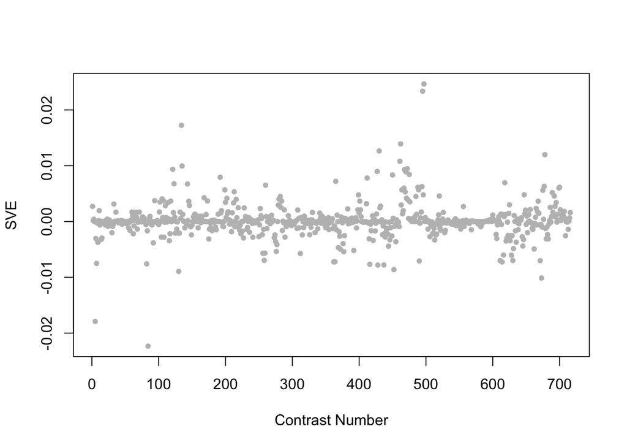

Positive SVE Contrasts:

|  | Contrast.Num | SVE | GEO.GSE | Cond.1 | Cond.2 | Mutation |
| --- | --- | --- | --- | --- | --- | --- |
| GSE23528C.s1t6.vs.s1t1 | 497 | 0.02 | GSE23528 | Adult at T46 in DD, time-series experiment 2 | Adult at T26 in DD, time-series experiment 2 |  |
| GSE23528C.s1t4.vs.s1t1 | 495 | 0.02 | GSE23528 | Adult at T38 in DD, time-series experiment 2 | Adult at T26 in DD, time-series experiment 2 |  |
| GSE52064.s1t1.vs.s4t1 | 134 | 0.02 | GSE52064 | wildtype_1 | lin-54;mes-4_1 | lin-54;mes-4 |
| GSE23528A.s2t3.vs.s0t3 | 462 | 0.01 | GSE23528 | Adult at T10 in WC, time-series experiment 1 | Adult at T10, non-entrained control time-series experiment 4 |  |
| GSE27677A.s1t1.vs.s0t1 | 430 | 0.01 | GSE27677 | kgb-1, Fed , rep 1 | N2, Fed , rep 1 | kgb-1 |

Negative SVE Contrasts:

|  | Contrast.Num | SVE | GEO.GSE | Cond.1 | Cond.2 | Mutation |
| --- | --- | --- | --- | --- | --- | --- |
| GSE6547.s2t2.vs.s0t2 | 84 | -0.02 | GSE6547 | slr-2(ku297) worms at L1 stage, first replicate | N2 (wt) worms at L1 stage, first replicate | sir-2 |
| GSE9897B.s2t1.vs.s0t1 | 5 | -0.02 | GSE9897 | Complex I RNAi Mutant 2 | Wildtype (control for RNAi) | Y45G12B.1 |
| GSE14640B.s1t1.vs.s0t1 | 673 | -0.01 | GSE14640 | XX_DPY27-N_042807_A | XX_WT-N_080307_A |  |
| GSE52064.s4t1.vs.s3t1 | 130 | -0.01 | GSE52064 | lin-54;mes-4_1 | lin-54_1 | mes-4 |
| GSE25633.s1t1.vs.s2t1 | 452 | -0.01 | GSE25633 | WT#1 | daf-19,daf-12#1 | daf-19;daf-12 |

$~$

#### Contrast SVE, Up-Regulated Genes Only:

Calculating SVE for up-regulated and down-regulated genes separately may be more informative in many cases than projecting the up- and down- gene sets together. This is due to the fact that the weight distribution of many modules is highly skewed, indicating that only one of the hemi-modules may be biologically meaningful (i.e., a set of genes are strongly correlated by only a few genes (or none) are strongly anti-correlated to that set.)

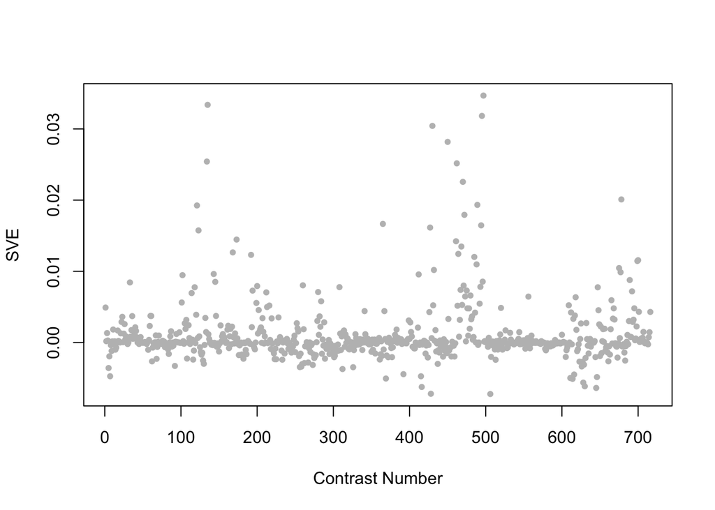

Positive SVE Contrasts:

|  | Contrast.Num | SVE | GEO.GSE | Cond.1 | Cond.2 | Mutation |
| --- | --- | --- | --- | --- | --- | --- |
| GSE23528C.s1t6.vs.s1t1 | 497 | 0.03 | GSE23528 | Adult at T46 in DD, time-series experiment 2 | Adult at T26 in DD, time-series experiment 2 |  |
| GSE52064.s1t1.vs.s2t1 | 135 | 0.03 | GSE52064 | wildtype_1 | mes-4_1 | mes-4 |
| GSE23528C.s1t4.vs.s1t1 | 495 | 0.03 | GSE23528 | Adult at T38 in DD, time-series experiment 2 | Adult at T26 in DD, time-series experiment 2 |  |
| GSE27677A.s1t1.vs.s0t1 | 430 | 0.03 | GSE27677 | kgb-1, Fed , rep 1 | N2, Fed , rep 1 | kgb-1 |
| GSE25633.s2t1.vs.s3t1 | 450 | 0.03 | GSE25633 | daf-19,daf-12#1 | daf-12#1 | daf-19 |

Negative SVE Contrasts:

|  | Contrast.Num | SVE | GEO.GSE | Cond.1 | Cond.2 | Mutation |
| --- | --- | --- | --- | --- | --- | --- |
| GSE2210.s1t1.vs.s0t1 | 506 | -0.01 | GSE2210 | tom-1(nu468) Sample 1 | Wild type Sample 1 | tom-1 |
| GSE27677A.s3t1.vs.s0t1 | 428 | -0.01 | GSE27677 | daf-16, Fed , rep 1 | N2, Fed , rep 1 | daf-16 |
| GSE16915.s2t1.vs.s3t1 | 645 | -0.01 | GSE16915 | positive control (heat shock) | bio-electrosprayed sample |  |
| GSE29951.s0t2.vs.s0t1 | 416 | -0.01 | GSE29951 | C.elegans wild type raised in the presence of Cd, rep1 | C.elegans wild type raised in the absence of Cd, rep1 |  |
| GSE19310A.s3t1.vs.s0t1 | 630 | -0.01 | GSE19310 | osm-8(n1518) at iso, rep1 | N2 at iso, rep1 | osm-8 |

$~$

#### Contrast SVE, Down-Regulated Genes Only:

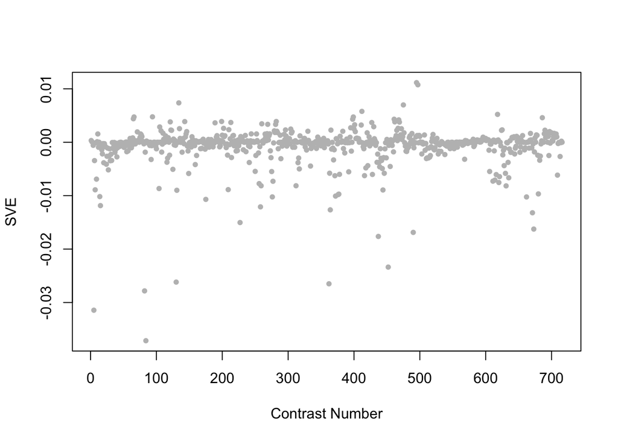

Positive SVE Contrasts:

|  | Contrast.Num | SVE | GEO.GSE | Cond.1 | Cond.2 | Mutation |
| --- | --- | --- | --- | --- | --- | --- |
| GSE23528C.s1t4.vs.s1t1 | 495 | 0.01 | GSE23528 | Adult at T38 in DD, time-series experiment 2 | Adult at T26 in DD, time-series experiment 2 |  |
| GSE23528C.s1t6.vs.s1t1 | 497 | 0.01 | GSE23528 | Adult at T46 in DD, time-series experiment 2 | Adult at T26 in DD, time-series experiment 2 |  |
| GSE52064.s1t1.vs.s4t1 | 134 | 0.01 | GSE52064 | wildtype_1 | lin-54;mes-4_1 | lin-54;mes-4 |
| GSE23528A.s1t5.vs.s1t1 | 475 | 0.01 | GSE23528 | Adult at T18 in LD, time-series experiment 3 | Adult at T2 in LD, time-series experiment 3 |  |
| GSE30505.s1t2.vs.s1t1 | 412 | 0.01 | GSE30505 | Day 8 N2 (WT) E.V. #1 | L3 N2 (WT) E.V. #1 |  |

Negative SVE Contrasts:

|  | Contrast.Num | SVE | GEO.GSE | Cond.1 | Cond.2 | Mutation |
| --- | --- | --- | --- | --- | --- | --- |
| GSE6547.s2t2.vs.s0t2 | 84 | -0.04 | GSE6547 | slr-2(ku297) worms at L1 stage, first replicate | N2 (wt) worms at L1 stage, first replicate | sir-2 |
| GSE9897B.s2t1.vs.s0t1 | 5 | -0.03 | GSE9897 | Complex I RNAi Mutant 2 | Wildtype (control for RNAi) | Y45G12B.1 |
| GSE7354.s2t1.vs.s1t1 | 82 | -0.03 | GSE7354 | whole animal, nucleus accumbens: Extract1_le1 | whole animal, nucleus accumbens: Extract-Control_le1 |  |
| GSE37266.s1t1.vs.s0t1 | 362 | -0.03 | GSE37266 | RPW-24 G | DMSO G |  |
| GSE52064.s4t1.vs.s3t1 | 130 | -0.03 | GSE52064 | lin-54;mes-4_1 | lin-54_1 | mes-4 |

$~$

$~$

#### GO Term Enrichment:

This analysis tests each hemi-module for enrichment of specific GO terms. Only gene-level annotations (e.g., as would be found on the gene’s page in Wormbase) are tested - the hierarchical structure of the GO ontology is not taken into account.

*Note: At least the top two most enriched terms from each GO domain (BP/MF/CC) are shown, even when not statistically significant.*

##### Enriched GO terms: Hemi-module A

| ID | GO.Term | GO Domain | Raw p-value | Adj p-value |
| --- | --- | --- | --- | --- |
| [GO_0035262](http://amigo.geneontology.org/amigo/term/GO:0035262) | gonad morphogenesis | BP | 1.46e-04 | 4.25e-01 |
| [GO_0006413](http://amigo.geneontology.org/amigo/term/GO:0006413) | translational initiation | BP | 3.21e-04 | 4.25e-01 |
| [GO_0042393](http://amigo.geneontology.org/amigo/term/GO:0042393) | histone binding | MF | 1.08e-04 | 2.21e-01 |
| [GO_0003743](http://amigo.geneontology.org/amigo/term/GO:0003743) | translation initiation factor activity | MF | 3.61e-04 | 3.69e-01 |
| [GO_0016021](http://amigo.geneontology.org/amigo/term/GO:0016021) | integral component of membrane | CC | 1.41e-04 | 8.74e-02 |
| [GO_0005737](http://amigo.geneontology.org/amigo/term/GO:0005737) | cytoplasm | CC | 1.88e-04 | 8.74e-02 |
| [GO_0016020](http://amigo.geneontology.org/amigo/term/GO:0016020) | membrane | CC | 3.74e-04 | 9.53e-02 |
| [GO_0016282](http://amigo.geneontology.org/amigo/term/GO:0016282) | eukaryotic 43S preinitiation complex | CC | 5.14e-04 | 9.53e-02 |
| [GO_0033290](http://amigo.geneontology.org/amigo/term/GO:0033290) | eukaryotic 48S preinitiation complex | CC | 5.14e-04 | 9.53e-02 |

##### Enriched GO terms: Hemi-module B

| ID | GO.Term | GO Domain | Raw p-value | Adj p-value |
| --- | --- | --- | --- | --- |
| [GO_0019835](http://amigo.geneontology.org/amigo/term/GO:0019835) | cytolysis | BP | 9.93e-06 | 3.62e-02 |
| [GO_0050830](http://amigo.geneontology.org/amigo/term/GO:0050830) | defense response to Gram-positive bacterium | BP | 6.96e-05 | 1.27e-01 |
| [GO_0003796](http://amigo.geneontology.org/amigo/term/GO:0003796) | lysozyme activity | MF | 7.41e-05 | 1.51e-01 |
| [GO_0003779](http://amigo.geneontology.org/amigo/term/GO:0003779) | actin binding | MF | 1.60e-04 | 1.64e-01 |
| [GO_0005764](http://amigo.geneontology.org/amigo/term/GO:0005764) | lysosome | CC | 2.48e-04 | 2.30e-01 |
| [GO_0031906](http://amigo.geneontology.org/amigo/term/GO:0031906) | late endosome lumen | CC | 1.33e-03 | 4.11e-01 |

$~$

$~$

#### Tissue Enrichment:

This analysis tests each hemi-module for enrichment of genes associated with anatomy terms. Negative enrichment scores indicate fewer hemi-module genes than expected by random chance were associated with the anatomy term in question.

##### Enriched tissues: Hemi-module A

| ID | Anatomy.Term | Definition | Raw p-value | Adj p-value |
| --- | --- | --- | --- | --- |
| [WBbt_0005784](https://wormbase.org/species/all/anatomy_term/WBbt:0005784) | germ line | cell line which early in development becomes differentiated from the remaining somatic cell line, and alone has the potential to undergo meiosis and form gametes. | 1.14e-05 | 2.77e-02 |

##### Enriched tissues: Hemi-module B

No significant annotations.

$~$

$~$

#### HOMER promoter motif enrichment:

This analysis tests each hemi-module for enrichment of 108 known *C. elegans* transcription factor binding site motifs (see [108 CE motifs](https://katiepod.github.io//all.worm.motifs.html)) using the HOMER (Hypergeometric Optimization of Motif EnRichment) software (see [PMID:20513432](https://pubmed.ncbi.nlm.nih.gov/20513432)). HOMER was run using default parameters on sequences 1 kb upstream of the transcription start site.

##### Motif enrichment: Hemi-module A

Total target sequences = 206  
Total background sequences = 35886  
* - possible false positive

Rank

Motif

P-value

log P-pvalue

% of Targets

% of Background

STD(Bg STD)

Best Match/Details

Motif File

1 *

[figure not shown]

1e-11

-2.603e+01

4.37%

0.10%

247.0bp (276.3bp)

hlh-30/MA1449.1/Jaspar(0.531)  
[More Information](https://katiepod.github.io/HomerResults/m136_a_hemi_genes.txt.out.1kb/homerResults/motif1.info.html) | [Similar Motifs Found](https://katiepod.github.io/HomerResults/m136_a_hemi_genes.txt.out.1kb/homerResults/motif1.similar.html)

[motif file (matrix)](https://katiepod.github.io/HomerResults/m136_a_hemi_genes.txt.out.1kb/homerResults/motif1.motif)

2 *

[figure not shown]

1e-11

-2.541e+01

3.88%

0.07%

179.8bp (431.3bp)

POL008.1_DCE_S_I/Jaspar(0.516)  
[More Information](https://katiepod.github.io/HomerResults/m136_a_hemi_genes.txt.out.1kb/homerResults/motif2.info.html) | [Similar Motifs Found](https://katiepod.github.io/HomerResults/m136_a_hemi_genes.txt.out.1kb/homerResults/motif2.similar.html)

[motif file (matrix)](https://katiepod.github.io/HomerResults/m136_a_hemi_genes.txt.out.1kb/homerResults/motif2.motif)

3 *

[figure not shown]

1e-10

-2.517e+01

47.09%

25.20%

297.2bp (404.0bp)

ceh-28/MA1445.1/Jaspar(0.809)  
[More Information](https://katiepod.github.io/HomerResults/m136_a_hemi_genes.txt.out.1kb/homerResults/motif3.info.html) | [Similar Motifs Found](https://katiepod.github.io/HomerResults/m136_a_hemi_genes.txt.out.1kb/homerResults/motif3.similar.html)

[motif file (matrix)](https://katiepod.github.io/HomerResults/m136_a_hemi_genes.txt.out.1kb/homerResults/motif3.motif)

4 *

[figure not shown]

1e-10

-2.478e+01

12.14%

2.26%

305.4bp (377.8bp)

pha-4/MA0546.1/Jaspar(0.523)  
[More Information](https://katiepod.github.io/HomerResults/m136_a_hemi_genes.txt.out.1kb/homerResults/motif4.info.html) | [Similar Motifs Found](https://katiepod.github.io/HomerResults/m136_a_hemi_genes.txt.out.1kb/homerResults/motif4.similar.html)

[motif file (matrix)](https://katiepod.github.io/HomerResults/m136_a_hemi_genes.txt.out.1kb/homerResults/motif4.motif)

5 *

[figure not shown]

1e-10

-2.443e+01

14.56%

3.36%

266.9bp (376.3bp)

blmp-1/MA0537.1/Jaspar(0.579)  
[More Information](https://katiepod.github.io/HomerResults/m136_a_hemi_genes.txt.out.1kb/homerResults/motif5.info.html) | [Similar Motifs Found](https://katiepod.github.io/HomerResults/m136_a_hemi_genes.txt.out.1kb/homerResults/motif5.similar.html)

[motif file (matrix)](https://katiepod.github.io/HomerResults/m136_a_hemi_genes.txt.out.1kb/homerResults/motif5.motif)

6 *

[figure not shown]

1e-10

-2.365e+01

2.91%

0.02%

205.4bp (158.4bp)

snpc-4/MA0544.1/Jaspar(0.504)  
[More Information](https://katiepod.github.io/HomerResults/m136_a_hemi_genes.txt.out.1kb/homerResults/motif6.info.html) | [Similar Motifs Found](https://katiepod.github.io/HomerResults/m136_a_hemi_genes.txt.out.1kb/homerResults/motif6.similar.html)

[motif file (matrix)](https://katiepod.github.io/HomerResults/m136_a_hemi_genes.txt.out.1kb/homerResults/motif6.motif)

7 *

[figure not shown]

1e-10

-2.347e+01

7.77%

0.85%

281.8bp (462.7bp)

POL010.1_DCE_S_III/Jaspar(0.563)  
[More Information](https://katiepod.github.io/HomerResults/m136_a_hemi_genes.txt.out.1kb/homerResults/motif7.info.html) | [Similar Motifs Found](https://katiepod.github.io/HomerResults/m136_a_hemi_genes.txt.out.1kb/homerResults/motif7.similar.html)

[motif file (matrix)](https://katiepod.github.io/HomerResults/m136_a_hemi_genes.txt.out.1kb/homerResults/motif7.motif)

8 *

[figure not shown]

1e-9

-2.187e+01

2.43%

0.01%

333.0bp (159.5bp)

POL011.1_XCPE1/Jaspar(0.519)  
[More Information](https://katiepod.github.io/HomerResults/m136_a_hemi_genes.txt.out.1kb/homerResults/motif8.info.html) | [Similar Motifs Found](https://katiepod.github.io/HomerResults/m136_a_hemi_genes.txt.out.1kb/homerResults/motif8.similar.html)

[motif file (matrix)](https://katiepod.github.io/HomerResults/m136_a_hemi_genes.txt.out.1kb/homerResults/motif8.motif)

9 *

[figure not shown]

1e-9

-2.173e+01

10.68%

2.01%

260.5bp (348.1bp)

PHA-4(Forkhead)/cElegans-Embryos-PHA4-ChIP-Seq(modEncode)/Homer(0.735)  
[More Information](https://katiepod.github.io/HomerResults/m136_a_hemi_genes.txt.out.1kb/homerResults/motif9.info.html) | [Similar Motifs Found](https://katiepod.github.io/HomerResults/m136_a_hemi_genes.txt.out.1kb/homerResults/motif9.similar.html)

[motif file (matrix)](https://katiepod.github.io/HomerResults/m136_a_hemi_genes.txt.out.1kb/homerResults/motif9.motif)

10 *

[figure not shown]

1e-9

-2.131e+01

24.76%

9.82%

296.3bp (380.8bp)

blmp-1/MA0537.1/Jaspar(0.555)  
[More Information](https://katiepod.github.io/HomerResults/m136_a_hemi_genes.txt.out.1kb/homerResults/motif10.info.html) | [Similar Motifs Found](https://katiepod.github.io/HomerResults/m136_a_hemi_genes.txt.out.1kb/homerResults/motif10.similar.html)

[motif file (matrix)](https://katiepod.github.io/HomerResults/m136_a_hemi_genes.txt.out.1kb/homerResults/motif10.motif)

11 *

[figure not shown]

1e-9

-2.111e+01

6.80%

0.72%

218.6bp (361.3bp)

POL013.1_MED-1/Jaspar(0.766)  
[More Information](https://katiepod.github.io/HomerResults/m136_a_hemi_genes.txt.out.1kb/homerResults/motif11.info.html) | [Similar Motifs Found](https://katiepod.github.io/HomerResults/m136_a_hemi_genes.txt.out.1kb/homerResults/motif11.similar.html)

[motif file (matrix)](https://katiepod.github.io/HomerResults/m136_a_hemi_genes.txt.out.1kb/homerResults/motif11.motif)

12 *

[figure not shown]

1e-9

-2.096e+01

4.37%

0.20%

244.9bp (321.9bp)

blmp-1/MA0537.1/Jaspar(0.588)  
[More Information](https://katiepod.github.io/HomerResults/m136_a_hemi_genes.txt.out.1kb/homerResults/motif12.info.html) | [Similar Motifs Found](https://katiepod.github.io/HomerResults/m136_a_hemi_genes.txt.out.1kb/homerResults/motif12.similar.html)

[motif file (matrix)](https://katiepod.github.io/HomerResults/m136_a_hemi_genes.txt.out.1kb/homerResults/motif12.motif)

13 *

[figure not shown]

1e-9

-2.089e+01

10.19%

1.91%

347.7bp (331.0bp)

lin-54/MA1450.1/Jaspar(0.591)  
[More Information](https://katiepod.github.io/HomerResults/m136_a_hemi_genes.txt.out.1kb/homerResults/motif13.info.html) | [Similar Motifs Found](https://katiepod.github.io/HomerResults/m136_a_hemi_genes.txt.out.1kb/homerResults/motif13.similar.html)

[motif file (matrix)](https://katiepod.github.io/HomerResults/m136_a_hemi_genes.txt.out.1kb/homerResults/motif13.motif)

14 *

[figure not shown]

1e-8

-2.053e+01

8.25%

1.21%

215.1bp (402.8bp)

pha-4/MA0546.1/Jaspar(0.588)  
[More Information](https://katiepod.github.io/HomerResults/m136_a_hemi_genes.txt.out.1kb/homerResults/motif14.info.html) | [Similar Motifs Found](https://katiepod.github.io/HomerResults/m136_a_hemi_genes.txt.out.1kb/homerResults/motif14.similar.html)

[motif file (matrix)](https://katiepod.github.io/HomerResults/m136_a_hemi_genes.txt.out.1kb/homerResults/motif14.motif)

15 *

[figure not shown]

1e-8

-1.977e+01

2.43%

0.02%

236.9bp (215.5bp)

fkh-9/MA1440.1/Jaspar(0.638)  
[More Information](https://katiepod.github.io/HomerResults/m136_a_hemi_genes.txt.out.1kb/homerResults/motif15.info.html) | [Similar Motifs Found](https://katiepod.github.io/HomerResults/m136_a_hemi_genes.txt.out.1kb/homerResults/motif15.similar.html)

[motif file (matrix)](https://katiepod.github.io/HomerResults/m136_a_hemi_genes.txt.out.1kb/homerResults/motif15.motif)

16 *

[figure not shown]

1e-8

-1.871e+01

44.17%

25.66%

295.6bp (333.7bp)

pqm-1/MA1703.1/Jaspar(0.758)  
[More Information](https://katiepod.github.io/HomerResults/m136_a_hemi_genes.txt.out.1kb/homerResults/motif16.info.html) | [Similar Motifs Found](https://katiepod.github.io/HomerResults/m136_a_hemi_genes.txt.out.1kb/homerResults/motif16.similar.html)

[motif file (matrix)](https://katiepod.github.io/HomerResults/m136_a_hemi_genes.txt.out.1kb/homerResults/motif16.motif)

17 *

[figure not shown]

1e-8

-1.852e+01

16.50%

5.42%

261.9bp (317.5bp)

lin-14/MA0261.1/Jaspar(0.590)  
[More Information](https://katiepod.github.io/HomerResults/m136_a_hemi_genes.txt.out.1kb/homerResults/motif17.info.html) | [Similar Motifs Found](https://katiepod.github.io/HomerResults/m136_a_hemi_genes.txt.out.1kb/homerResults/motif17.similar.html)

[motif file (matrix)](https://katiepod.github.io/HomerResults/m136_a_hemi_genes.txt.out.1kb/homerResults/motif17.motif)

18 *

[figure not shown]

1e-7

-1.841e+01

4.37%

0.27%

272.7bp (314.4bp)

dpy-27/MA0540.1/Jaspar(0.514)  
[More Information](https://katiepod.github.io/HomerResults/m136_a_hemi_genes.txt.out.1kb/homerResults/motif18.info.html) | [Similar Motifs Found](https://katiepod.github.io/HomerResults/m136_a_hemi_genes.txt.out.1kb/homerResults/motif18.similar.html)

[motif file (matrix)](https://katiepod.github.io/HomerResults/m136_a_hemi_genes.txt.out.1kb/homerResults/motif18.motif)

19 *

[figure not shown]

1e-7

-1.759e+01

29.13%

14.12%

283.0bp (398.8bp)

MF0001.1_ETS_class/Jaspar(0.664)  
[More Information](https://katiepod.github.io/HomerResults/m136_a_hemi_genes.txt.out.1kb/homerResults/motif19.info.html) | [Similar Motifs Found](https://katiepod.github.io/HomerResults/m136_a_hemi_genes.txt.out.1kb/homerResults/motif19.similar.html)

[motif file (matrix)](https://katiepod.github.io/HomerResults/m136_a_hemi_genes.txt.out.1kb/homerResults/motif19.motif)

20 *

[figure not shown]

1e-7

-1.677e+01

39.81%

22.94%

283.0bp (346.8bp)

blmp-1/MA0537.1/Jaspar(0.658)  
[More Information](https://katiepod.github.io/HomerResults/m136_a_hemi_genes.txt.out.1kb/homerResults/motif20.info.html) | [Similar Motifs Found](https://katiepod.github.io/HomerResults/m136_a_hemi_genes.txt.out.1kb/homerResults/motif20.similar.html)

[motif file (matrix)](https://katiepod.github.io/HomerResults/m136_a_hemi_genes.txt.out.1kb/homerResults/motif20.motif)

21 *

[figure not shown]

1e-7

-1.652e+01

8.25%

1.61%

298.0bp (324.2bp)

che-1/MA0260.1/Jaspar(0.526)  
[More Information](https://katiepod.github.io/HomerResults/m136_a_hemi_genes.txt.out.1kb/homerResults/motif21.info.html) | [Similar Motifs Found](https://katiepod.github.io/HomerResults/m136_a_hemi_genes.txt.out.1kb/homerResults/motif21.similar.html)

[motif file (matrix)](https://katiepod.github.io/HomerResults/m136_a_hemi_genes.txt.out.1kb/homerResults/motif21.motif)

22 *

[figure not shown]

1e-6

-1.482e+01

2.91%

0.12%

250.7bp (344.7bp)

POL008.1_DCE_S_I/Jaspar(0.553)  
[More Information](https://katiepod.github.io/HomerResults/m136_a_hemi_genes.txt.out.1kb/homerResults/motif22.info.html) | [Similar Motifs Found](https://katiepod.github.io/HomerResults/m136_a_hemi_genes.txt.out.1kb/homerResults/motif22.similar.html)

[motif file (matrix)](https://katiepod.github.io/HomerResults/m136_a_hemi_genes.txt.out.1kb/homerResults/motif22.motif)

23 *

[figure not shown]

1e-5

-1.372e+01

33.50%

19.27%

298.4bp (360.0bp)

cebp-1/MA1444.1/Jaspar(0.563)  
[More Information](https://katiepod.github.io/HomerResults/m136_a_hemi_genes.txt.out.1kb/homerResults/motif23.info.html) | [Similar Motifs Found](https://katiepod.github.io/HomerResults/m136_a_hemi_genes.txt.out.1kb/homerResults/motif23.similar.html)

[motif file (matrix)](https://katiepod.github.io/HomerResults/m136_a_hemi_genes.txt.out.1kb/homerResults/motif23.motif)

24 *

[figure not shown]

1e-5

-1.302e+01

21.36%

10.24%

305.3bp (365.4bp)

EFL-1(E2F)/cElegans-L1-EFL1-ChIP-Seq(modEncode)/Homer(0.615)  
[More Information](https://katiepod.github.io/HomerResults/m136_a_hemi_genes.txt.out.1kb/homerResults/motif24.info.html) | [Similar Motifs Found](https://katiepod.github.io/HomerResults/m136_a_hemi_genes.txt.out.1kb/homerResults/motif24.similar.html)

[motif file (matrix)](https://katiepod.github.io/HomerResults/m136_a_hemi_genes.txt.out.1kb/homerResults/motif24.motif)

25 *

[figure not shown]

1e-5

-1.277e+01

2.43%

0.10%

183.4bp (304.8bp)

PL0017.1_hlh-2::hlh-10/Jaspar(0.585)  
[More Information](https://katiepod.github.io/HomerResults/m136_a_hemi_genes.txt.out.1kb/homerResults/motif25.info.html) | [Similar Motifs Found](https://katiepod.github.io/HomerResults/m136_a_hemi_genes.txt.out.1kb/homerResults/motif25.similar.html)

[motif file (matrix)](https://katiepod.github.io/HomerResults/m136_a_hemi_genes.txt.out.1kb/homerResults/motif25.motif)

26 *

[figure not shown]

1e-5

-1.234e+01

6.31%

1.30%

300.6bp (356.3bp)

daf-12/MA0538.1/Jaspar(0.734)  
[More Information](https://katiepod.github.io/HomerResults/m136_a_hemi_genes.txt.out.1kb/homerResults/motif26.info.html) | [Similar Motifs Found](https://katiepod.github.io/HomerResults/m136_a_hemi_genes.txt.out.1kb/homerResults/motif26.similar.html)

[motif file (matrix)](https://katiepod.github.io/HomerResults/m136_a_hemi_genes.txt.out.1kb/homerResults/motif26.motif)

27 *

[figure not shown]

1e-5

-1.181e+01

15.53%

6.64%

300.2bp (349.7bp)

POL004.1_CCAAT-box/Jaspar(0.742)  
[More Information](https://katiepod.github.io/HomerResults/m136_a_hemi_genes.txt.out.1kb/homerResults/motif27.info.html) | [Similar Motifs Found](https://katiepod.github.io/HomerResults/m136_a_hemi_genes.txt.out.1kb/homerResults/motif27.similar.html)

[motif file (matrix)](https://katiepod.github.io/HomerResults/m136_a_hemi_genes.txt.out.1kb/homerResults/motif27.motif)

28 *

[figure not shown]

1e-4

-1.046e+01

14.08%

6.12%

282.9bp (382.1bp)

efl-1/MA0541.1/Jaspar(0.546)  
[More Information](https://katiepod.github.io/HomerResults/m136_a_hemi_genes.txt.out.1kb/homerResults/motif28.info.html) | [Similar Motifs Found](https://katiepod.github.io/HomerResults/m136_a_hemi_genes.txt.out.1kb/homerResults/motif28.similar.html)

[motif file (matrix)](https://katiepod.github.io/HomerResults/m136_a_hemi_genes.txt.out.1kb/homerResults/motif28.motif)

29 *

[figure not shown]

1e-4

-1.030e+01

16.99%

8.19%

273.9bp (348.9bp)

zip-8/MA1704.1/Jaspar(0.608)  
[More Information](https://katiepod.github.io/HomerResults/m136_a_hemi_genes.txt.out.1kb/homerResults/motif29.info.html) | [Similar Motifs Found](https://katiepod.github.io/HomerResults/m136_a_hemi_genes.txt.out.1kb/homerResults/motif29.similar.html)

[motif file (matrix)](https://katiepod.github.io/HomerResults/m136_a_hemi_genes.txt.out.1kb/homerResults/motif29.motif)

30 *

[figure not shown]

1e-4

-1.014e+01

46.12%

32.61%

280.1bp (376.9bp)

POL008.1_DCE_S_I/Jaspar(0.586)  
[More Information](https://katiepod.github.io/HomerResults/m136_a_hemi_genes.txt.out.1kb/homerResults/motif30.info.html) | [Similar Motifs Found](https://katiepod.github.io/HomerResults/m136_a_hemi_genes.txt.out.1kb/homerResults/motif30.similar.html)

[motif file (matrix)](https://katiepod.github.io/HomerResults/m136_a_hemi_genes.txt.out.1kb/homerResults/motif30.motif)

31 *

[figure not shown]

1e-3

-9.026e+00

6.80%

2.06%

248.6bp (362.6bp)

PL0004.1_hlh-27/Jaspar(0.542)  
[More Information](https://katiepod.github.io/HomerResults/m136_a_hemi_genes.txt.out.1kb/homerResults/motif31.info.html) | [Similar Motifs Found](https://katiepod.github.io/HomerResults/m136_a_hemi_genes.txt.out.1kb/homerResults/motif31.similar.html)

[motif file (matrix)](https://katiepod.github.io/HomerResults/m136_a_hemi_genes.txt.out.1kb/homerResults/motif31.motif)

32 *

[figure not shown]

1e-1

-3.388e+00

0.49%

0.01%

28.3bp (317.5bp)

MF0004.1_Nuclear_Receptor_class/Jaspar(0.504)  
[More Information](https://katiepod.github.io/HomerResults/m136_a_hemi_genes.txt.out.1kb/homerResults/motif32.info.html) | [Similar Motifs Found](https://katiepod.github.io/HomerResults/m136_a_hemi_genes.txt.out.1kb/homerResults/motif32.similar.html)

[motif file (matrix)](https://katiepod.github.io/HomerResults/m136_a_hemi_genes.txt.out.1kb/homerResults/motif32.motif)

##### Motif enrichment: Hemi-module B

Total target sequences = 18  
Total background sequences = 36450  
* - possible false positive

Rank

Motif

P-value

log P-pvalue

% of Targets

% of Background

STD(Bg STD)

Best Match/Details

Motif File

1 *

[figure not shown]

1e-9

-2.161e+01

27.78%

0.21%

274.4bp (277.8bp)

PL0005.1_hlh-30/Jaspar(0.510)  
[More Information](https://katiepod.github.io/HomerResults/m136_b_hemi_genes.txt.out.1kb/homerResults/motif1.info.html) | [Similar Motifs Found](https://katiepod.github.io/HomerResults/m136_b_hemi_genes.txt.out.1kb/homerResults/motif1.similar.html)

[motif file (matrix)](https://katiepod.github.io/HomerResults/m136_b_hemi_genes.txt.out.1kb/homerResults/motif1.motif)

2 *

[figure not shown]

1e-8

-1.856e+01

27.78%

0.40%

334.3bp (432.9bp)

MF0002.1_bZIP_CREB/G-box-like_subclass/Jaspar(0.629)  
[More Information](https://katiepod.github.io/HomerResults/m136_b_hemi_genes.txt.out.1kb/homerResults/motif2.info.html) | [Similar Motifs Found](https://katiepod.github.io/HomerResults/m136_b_hemi_genes.txt.out.1kb/homerResults/motif2.similar.html)

[motif file (matrix)](https://katiepod.github.io/HomerResults/m136_b_hemi_genes.txt.out.1kb/homerResults/motif2.motif)

3 *

[figure not shown]

1e-5

-1.336e+01

16.67%

0.12%

220.0bp (323.6bp)

PHA-4(Forkhead)/cElegans-Embryos-PHA4-ChIP-Seq(modEncode)/Homer(0.581)  
[More Information](https://katiepod.github.io/HomerResults/m136_b_hemi_genes.txt.out.1kb/homerResults/motif3.info.html) | [Similar Motifs Found](https://katiepod.github.io/HomerResults/m136_b_hemi_genes.txt.out.1kb/homerResults/motif3.similar.html)

[motif file (matrix)](https://katiepod.github.io/HomerResults/m136_b_hemi_genes.txt.out.1kb/homerResults/motif3.motif)

4 *

[figure not shown]

1e-5

-1.191e+01

44.44%

6.37%

319.0bp (440.8bp)

daf-12/MA0538.1/Jaspar(0.739)  
[More Information](https://katiepod.github.io/HomerResults/m136_b_hemi_genes.txt.out.1kb/homerResults/motif4.info.html) | [Similar Motifs Found](https://katiepod.github.io/HomerResults/m136_b_hemi_genes.txt.out.1kb/homerResults/motif4.similar.html)

[motif file (matrix)](https://katiepod.github.io/HomerResults/m136_b_hemi_genes.txt.out.1kb/homerResults/motif4.motif)

5 *

[figure not shown]

1e-4

-1.094e+01

11.11%

0.03%

169.7bp (164.1bp)

MF0010.1_Homeobox_class/Jaspar(0.524)  
[More Information](https://katiepod.github.io/HomerResults/m136_b_hemi_genes.txt.out.1kb/homerResults/motif5.info.html) | [Similar Motifs Found](https://katiepod.github.io/HomerResults/m136_b_hemi_genes.txt.out.1kb/homerResults/motif5.similar.html)

[motif file (matrix)](https://katiepod.github.io/HomerResults/m136_b_hemi_genes.txt.out.1kb/homerResults/motif5.motif)

6 *

[figure not shown]

1e-4

-1.035e+01

50.00%

10.53%

327.4bp (394.1bp)

eor-1/MA0543.1/Jaspar(0.705)  
[More Information](https://katiepod.github.io/HomerResults/m136_b_hemi_genes.txt.out.1kb/homerResults/motif6.info.html) | [Similar Motifs Found](https://katiepod.github.io/HomerResults/m136_b_hemi_genes.txt.out.1kb/homerResults/motif6.similar.html)

[motif file (matrix)](https://katiepod.github.io/HomerResults/m136_b_hemi_genes.txt.out.1kb/homerResults/motif6.motif)

7 *

[figure not shown]

1e-4

-1.001e+01

33.33%

3.92%

209.4bp (345.5bp)

PL0011.1_hlh-2::hlh-4/Jaspar(0.550)  
[More Information](https://katiepod.github.io/HomerResults/m136_b_hemi_genes.txt.out.1kb/homerResults/motif7.info.html) | [Similar Motifs Found](https://katiepod.github.io/HomerResults/m136_b_hemi_genes.txt.out.1kb/homerResults/motif7.similar.html)

[motif file (matrix)](https://katiepod.github.io/HomerResults/m136_b_hemi_genes.txt.out.1kb/homerResults/motif7.motif)

8 *

[figure not shown]

1e-4

-9.611e+00

38.89%

6.29%

327.7bp (425.7bp)

POL009.1_DCE_S_II/Jaspar(0.531)  
[More Information](https://katiepod.github.io/HomerResults/m136_b_hemi_genes.txt.out.1kb/homerResults/motif8.info.html) | [Similar Motifs Found](https://katiepod.github.io/HomerResults/m136_b_hemi_genes.txt.out.1kb/homerResults/motif8.similar.html)

[motif file (matrix)](https://katiepod.github.io/HomerResults/m136_b_hemi_genes.txt.out.1kb/homerResults/motif8.motif)

9 *

[figure not shown]

1e-3

-8.498e+00

27.78%

3.20%

178.3bp (400.3bp)

MF0001.1_ETS_class/Jaspar(0.641)  
[More Information](https://katiepod.github.io/HomerResults/m136_b_hemi_genes.txt.out.1kb/homerResults/motif9.info.html) | [Similar Motifs Found](https://katiepod.github.io/HomerResults/m136_b_hemi_genes.txt.out.1kb/homerResults/motif9.similar.html)

[motif file (matrix)](https://katiepod.github.io/HomerResults/m136_b_hemi_genes.txt.out.1kb/homerResults/motif9.motif)

10 *

[figure not shown]

1e-3

-8.145e+00

27.78%

3.45%

230.1bp (371.4bp)

POL004.1_CCAAT-box/Jaspar(0.590)  
[More Information](https://katiepod.github.io/HomerResults/m136_b_hemi_genes.txt.out.1kb/homerResults/motif10.info.html) | [Similar Motifs Found](https://katiepod.github.io/HomerResults/m136_b_hemi_genes.txt.out.1kb/homerResults/motif10.similar.html)

[motif file (matrix)](https://katiepod.github.io/HomerResults/m136_b_hemi_genes.txt.out.1kb/homerResults/motif10.motif)

11 *

[figure not shown]

1e-3

-7.625e+00

38.89%

8.64%

307.8bp (390.4bp)

MF0011.1_HMG_class/Jaspar(0.664)  
[More Information](https://katiepod.github.io/HomerResults/m136_b_hemi_genes.txt.out.1kb/homerResults/motif11.info.html) | [Similar Motifs Found](https://katiepod.github.io/HomerResults/m136_b_hemi_genes.txt.out.1kb/homerResults/motif11.similar.html)

[motif file (matrix)](https://katiepod.github.io/HomerResults/m136_b_hemi_genes.txt.out.1kb/homerResults/motif11.motif)

12 *

[figure not shown]

1e-3

-7.620e+00

5.56%

0.00%

0.0bp (0.0bp)

POL013.1_MED-1/Jaspar(0.571)  
[More Information](https://katiepod.github.io/HomerResults/m136_b_hemi_genes.txt.out.1kb/homerResults/motif12.info.html) | [Similar Motifs Found](https://katiepod.github.io/HomerResults/m136_b_hemi_genes.txt.out.1kb/homerResults/motif12.similar.html)

[motif file (matrix)](https://katiepod.github.io/HomerResults/m136_b_hemi_genes.txt.out.1kb/homerResults/motif12.motif)

13 *

[figure not shown]

1e-3

-7.620e+00

5.56%

0.00%

0.0bp (0.0bp)

POL011.1_XCPE1/Jaspar(0.555)  
[More Information](https://katiepod.github.io/HomerResults/m136_b_hemi_genes.txt.out.1kb/homerResults/motif13.info.html) | [Similar Motifs Found](https://katiepod.github.io/HomerResults/m136_b_hemi_genes.txt.out.1kb/homerResults/motif13.similar.html)

[motif file (matrix)](https://katiepod.github.io/HomerResults/m136_b_hemi_genes.txt.out.1kb/homerResults/motif13.motif)

14 *

[figure not shown]

1e-3

-7.620e+00

5.56%

0.00%

0.0bp (9.4bp)

sma-4/MA0925.1/Jaspar(0.605)  
[More Information](https://katiepod.github.io/HomerResults/m136_b_hemi_genes.txt.out.1kb/homerResults/motif14.info.html) | [Similar Motifs Found](https://katiepod.github.io/HomerResults/m136_b_hemi_genes.txt.out.1kb/homerResults/motif14.similar.html)

[motif file (matrix)](https://katiepod.github.io/HomerResults/m136_b_hemi_genes.txt.out.1kb/homerResults/motif14.motif)

15 *

[figure not shown]

1e-3

-7.620e+00

5.56%

0.00%

0.0bp (0.0bp)

POL006.1_BREu/Jaspar(0.621)  
[More Information](https://katiepod.github.io/HomerResults/m136_b_hemi_genes.txt.out.1kb/homerResults/motif15.info.html) | [Similar Motifs Found](https://katiepod.github.io/HomerResults/m136_b_hemi_genes.txt.out.1kb/homerResults/motif15.similar.html)

[motif file (matrix)](https://katiepod.github.io/HomerResults/m136_b_hemi_genes.txt.out.1kb/homerResults/motif15.motif)

16 *

[figure not shown]

1e-3

-7.620e+00

5.56%

0.00%

0.0bp (0.0bp)

POL011.1_XCPE1/Jaspar(0.572)  
[More Information](https://katiepod.github.io/HomerResults/m136_b_hemi_genes.txt.out.1kb/homerResults/motif16.info.html) | [Similar Motifs Found](https://katiepod.github.io/HomerResults/m136_b_hemi_genes.txt.out.1kb/homerResults/motif16.similar.html)

[motif file (matrix)](https://katiepod.github.io/HomerResults/m136_b_hemi_genes.txt.out.1kb/homerResults/motif16.motif)

17 *

[figure not shown]

1e-3

-7.620e+00

5.56%

0.00%

0.0bp (0.0bp)

SD0001.1_at_AC_acceptor/Jaspar(0.536)  
[More Information](https://katiepod.github.io/HomerResults/m136_b_hemi_genes.txt.out.1kb/homerResults/motif17.info.html) | [Similar Motifs Found](https://katiepod.github.io/HomerResults/m136_b_hemi_genes.txt.out.1kb/homerResults/motif17.similar.html)

[motif file (matrix)](https://katiepod.github.io/HomerResults/m136_b_hemi_genes.txt.out.1kb/homerResults/motif17.motif)

18 *

[figure not shown]

1e-3

-7.620e+00

5.56%

0.00%

0.0bp (50.4bp)

POL004.1_CCAAT-box/Jaspar(0.596)  
[More Information](https://katiepod.github.io/HomerResults/m136_b_hemi_genes.txt.out.1kb/homerResults/motif18.info.html) | [Similar Motifs Found](https://katiepod.github.io/HomerResults/m136_b_hemi_genes.txt.out.1kb/homerResults/motif18.similar.html)

[motif file (matrix)](https://katiepod.github.io/HomerResults/m136_b_hemi_genes.txt.out.1kb/homerResults/motif18.motif)

19 *

[figure not shown]

1e-3

-7.620e+00

5.56%

0.00%

0.0bp (23.7bp)

POL013.1_MED-1/Jaspar(0.687)  
[More Information](https://katiepod.github.io/HomerResults/m136_b_hemi_genes.txt.out.1kb/homerResults/motif19.info.html) | [Similar Motifs Found](https://katiepod.github.io/HomerResults/m136_b_hemi_genes.txt.out.1kb/homerResults/motif19.similar.html)

[motif file (matrix)](https://katiepod.github.io/HomerResults/m136_b_hemi_genes.txt.out.1kb/homerResults/motif19.motif)

20 *

[figure not shown]

1e-3

-7.620e+00

5.56%

0.00%

0.0bp (158.1bp)

MF0004.1_Nuclear_Receptor_class/Jaspar(0.671)  
[More Information](https://katiepod.github.io/HomerResults/m136_b_hemi_genes.txt.out.1kb/homerResults/motif20.info.html) | [Similar Motifs Found](https://katiepod.github.io/HomerResults/m136_b_hemi_genes.txt.out.1kb/homerResults/motif20.similar.html)

[motif file (matrix)](https://katiepod.github.io/HomerResults/m136_b_hemi_genes.txt.out.1kb/homerResults/motif20.motif)

21 *

[figure not shown]

1e-3

-7.620e+00

5.56%

0.00%

0.0bp (0.0bp)

unc-62/MA0918.1/Jaspar(0.555)  
[More Information](https://katiepod.github.io/HomerResults/m136_b_hemi_genes.txt.out.1kb/homerResults/motif21.info.html) | [Similar Motifs Found](https://katiepod.github.io/HomerResults/m136_b_hemi_genes.txt.out.1kb/homerResults/motif21.similar.html)

[motif file (matrix)](https://katiepod.github.io/HomerResults/m136_b_hemi_genes.txt.out.1kb/homerResults/motif21.motif)

22 *

[figure not shown]

1e-3

-7.620e+00

5.56%

0.00%

0.0bp (0.0bp)

hlh-1/MA0545.1/Jaspar(0.578)  
[More Information](https://katiepod.github.io/HomerResults/m136_b_hemi_genes.txt.out.1kb/homerResults/motif22.info.html) | [Similar Motifs Found](https://katiepod.github.io/HomerResults/m136_b_hemi_genes.txt.out.1kb/homerResults/motif22.similar.html)

[motif file (matrix)](https://katiepod.github.io/HomerResults/m136_b_hemi_genes.txt.out.1kb/homerResults/motif22.motif)

23 *

[figure not shown]

1e-3

-7.620e+00

5.56%

0.00%

0.0bp (0.0bp)

POL009.1_DCE_S_II/Jaspar(0.491)  
[More Information](https://katiepod.github.io/HomerResults/m136_b_hemi_genes.txt.out.1kb/homerResults/motif23.info.html) | [Similar Motifs Found](https://katiepod.github.io/HomerResults/m136_b_hemi_genes.txt.out.1kb/homerResults/motif23.similar.html)

[motif file (matrix)](https://katiepod.github.io/HomerResults/m136_b_hemi_genes.txt.out.1kb/homerResults/motif23.motif)

24 *

[figure not shown]

1e-3

-7.620e+00

5.56%

0.00%

0.0bp (0.0bp)

lin-14/MA0261.1/Jaspar(0.654)  
[More Information](https://katiepod.github.io/HomerResults/m136_b_hemi_genes.txt.out.1kb/homerResults/motif24.info.html) | [Similar Motifs Found](https://katiepod.github.io/HomerResults/m136_b_hemi_genes.txt.out.1kb/homerResults/motif24.similar.html)

[motif file (matrix)](https://katiepod.github.io/HomerResults/m136_b_hemi_genes.txt.out.1kb/homerResults/motif24.motif)

25 *

[figure not shown]

1e-3

-7.620e+00

5.56%

0.00%

0.0bp (130.2bp)

che-1/MA0260.1/Jaspar(0.654)  
[More Information](https://katiepod.github.io/HomerResults/m136_b_hemi_genes.txt.out.1kb/homerResults/motif25.info.html) | [Similar Motifs Found](https://katiepod.github.io/HomerResults/m136_b_hemi_genes.txt.out.1kb/homerResults/motif25.similar.html)

[motif file (matrix)](https://katiepod.github.io/HomerResults/m136_b_hemi_genes.txt.out.1kb/homerResults/motif25.motif)

26 *

[figure not shown]

1e-3

-7.620e+00

5.56%

0.00%

0.0bp (0.0bp)

POL010.1_DCE_S_III/Jaspar(0.483)  
[More Information](https://katiepod.github.io/HomerResults/m136_b_hemi_genes.txt.out.1kb/homerResults/motif26.info.html) | [Similar Motifs Found](https://katiepod.github.io/HomerResults/m136_b_hemi_genes.txt.out.1kb/homerResults/motif26.similar.html)

[motif file (matrix)](https://katiepod.github.io/HomerResults/m136_b_hemi_genes.txt.out.1kb/homerResults/motif26.motif)

27 *

[figure not shown]

1e-3

-7.620e+00

5.56%

0.00%

0.0bp (0.0bp)

atf-7/MA1438.1/Jaspar(0.563)  
[More Information](https://katiepod.github.io/HomerResults/m136_b_hemi_genes.txt.out.1kb/homerResults/motif27.info.html) | [Similar Motifs Found](https://katiepod.github.io/HomerResults/m136_b_hemi_genes.txt.out.1kb/homerResults/motif27.similar.html)

[motif file (matrix)](https://katiepod.github.io/HomerResults/m136_b_hemi_genes.txt.out.1kb/homerResults/motif27.motif)

28 *

[figure not shown]

1e-3

-7.620e+00

5.56%

0.00%

0.0bp (0.0bp)

lim-7/MA1441.1/Jaspar(0.477)  
[More Information](https://katiepod.github.io/HomerResults/m136_b_hemi_genes.txt.out.1kb/homerResults/motif28.info.html) | [Similar Motifs Found](https://katiepod.github.io/HomerResults/m136_b_hemi_genes.txt.out.1kb/homerResults/motif28.similar.html)

[motif file (matrix)](https://katiepod.github.io/HomerResults/m136_b_hemi_genes.txt.out.1kb/homerResults/motif28.motif)

29 *

[figure not shown]

1e-3

-7.620e+00

5.56%

0.00%

0.0bp (0.0bp)

POL009.1_DCE_S_II/Jaspar(0.553)  
[More Information](https://katiepod.github.io/HomerResults/m136_b_hemi_genes.txt.out.1kb/homerResults/motif29.info.html) | [Similar Motifs Found](https://katiepod.github.io/HomerResults/m136_b_hemi_genes.txt.out.1kb/homerResults/motif29.similar.html)

[motif file (matrix)](https://katiepod.github.io/HomerResults/m136_b_hemi_genes.txt.out.1kb/homerResults/motif29.motif)

30 *

[figure not shown]

1e-3

-7.620e+00

5.56%

0.00%

0.0bp (0.0bp)

nhr-6/MA1451.1/Jaspar(0.601)  
[More Information](https://katiepod.github.io/HomerResults/m136_b_hemi_genes.txt.out.1kb/homerResults/motif30.info.html) | [Similar Motifs Found](https://katiepod.github.io/HomerResults/m136_b_hemi_genes.txt.out.1kb/homerResults/motif30.similar.html)

[motif file (matrix)](https://katiepod.github.io/HomerResults/m136_b_hemi_genes.txt.out.1kb/homerResults/motif30.motif)

31 *

[figure not shown]

1e-3

-7.620e+00

5.56%

0.00%

0.0bp (0.0bp)

che-1/MA0260.1/Jaspar(0.564)  
[More Information](https://katiepod.github.io/HomerResults/m136_b_hemi_genes.txt.out.1kb/homerResults/motif31.info.html) | [Similar Motifs Found](https://katiepod.github.io/HomerResults/m136_b_hemi_genes.txt.out.1kb/homerResults/motif31.similar.html)

[motif file (matrix)](https://katiepod.github.io/HomerResults/m136_b_hemi_genes.txt.out.1kb/homerResults/motif31.motif)

32 *

[figure not shown]

1e-3

-6.928e+00

5.56%

0.00%

0.0bp (27.5bp)

MF0001.1_ETS_class/Jaspar(0.554)  
[More Information](https://katiepod.github.io/HomerResults/m136_b_hemi_genes.txt.out.1kb/homerResults/motif32.info.html) | [Similar Motifs Found](https://katiepod.github.io/HomerResults/m136_b_hemi_genes.txt.out.1kb/homerResults/motif32.similar.html)

[motif file (matrix)](https://katiepod.github.io/HomerResults/m136_b_hemi_genes.txt.out.1kb/homerResults/motif32.motif)

33 *

[figure not shown]

1e-2

-6.761e+00

11.11%

0.28%

32.0bp (293.4bp)

zfh-2/MA0928.1/Jaspar(0.600)  
[More Information](https://katiepod.github.io/HomerResults/m136_b_hemi_genes.txt.out.1kb/homerResults/motif33.info.html) | [Similar Motifs Found](https://katiepod.github.io/HomerResults/m136_b_hemi_genes.txt.out.1kb/homerResults/motif33.similar.html)

[motif file (matrix)](https://katiepod.github.io/HomerResults/m136_b_hemi_genes.txt.out.1kb/homerResults/motif33.motif)

34 *

[figure not shown]

1e-2

-6.287e+00

33.33%

7.82%

290.0bp (375.8bp)

POL009.1_DCE_S_II/Jaspar(0.711)  
[More Information](https://katiepod.github.io/HomerResults/m136_b_hemi_genes.txt.out.1kb/homerResults/motif34.info.html) | [Similar Motifs Found](https://katiepod.github.io/HomerResults/m136_b_hemi_genes.txt.out.1kb/homerResults/motif34.similar.html)

[motif file (matrix)](https://katiepod.github.io/HomerResults/m136_b_hemi_genes.txt.out.1kb/homerResults/motif34.motif)

35 *

[figure not shown]

1e-2

-6.213e+00

22.22%

3.10%

256.5bp (376.6bp)

lin-14/MA0261.1/Jaspar(0.627)  
[More Information](https://katiepod.github.io/HomerResults/m136_b_hemi_genes.txt.out.1kb/homerResults/motif35.info.html) | [Similar Motifs Found](https://katiepod.github.io/HomerResults/m136_b_hemi_genes.txt.out.1kb/homerResults/motif35.similar.html)

[motif file (matrix)](https://katiepod.github.io/HomerResults/m136_b_hemi_genes.txt.out.1kb/homerResults/motif35.motif)

$~$

$~$

#### Promoter Word Enrichment:

This analysis tests each hemi-module for enrichment of specific promoter words. The list of promoter words tested was generated by running the MobyDick algorithm (see [PMID:10944202](https://pubmed.ncbi.nlm.nih.gov/10944202)) on the full set of *C. elegans* 2 Kbp promoters.

##### Enriched promoter words: Hemi-module A

| Word | RC | Raw.p.value | Adj.p.value |
| --- | --- | --- | --- |
| AAAAATCGAT | ATCGATTTTT | 1.34e-08 | 7.03e-05 |
| AAATCGA | TCGATTT | 1.15e-07 | 3.01e-04 |
| AAAAATCG | CGATTTTT | 3.75e-07 | 6.23e-04 |
| CGATTTTTC | GAAAAATCG | 4.77e-07 | 6.23e-04 |
| CGATTTTT | AAAAATCG | 2.45e-06 | 2.56e-03 |
| TCGATTTTTC | GAAAAATCGA | 3.28e-06 | 2.86e-03 |
| GGGTACGGTA | TACCGTACCC | 4.84e-06 | 3.36e-03 |
| ATTTTCC | GGAAAAT | 5.14e-06 | 3.36e-03 |
| TCGATTT | AAATCGA | 5.93e-06 | 3.45e-03 |
| GAATTTCG | CGAAATTC | 1.48e-05 | 7.72e-03 |
| CGATTTTC | GAAAATCG | 1.72e-05 | 8.16e-03 |
| GCGTC | GACGC | 3.25e-05 | 1.35e-02 |
| AAAATCGATAA | TTATCGATTTT | 3.78e-05 | 1.35e-02 |
| TATTGATTTTT | AAAAATCAATA | 3.82e-05 | 1.35e-02 |
| CCGGAA | TTCCGG | 3.88e-05 | 1.35e-02 |
| AAAAATCGA | TCGATTTTT | 4.38e-05 | 1.35e-02 |
| AAAAATCGATAA | TTATCGATTTTT | 4.61e-05 | 1.35e-02 |
| CGCCCCG | CGGGGCG | 4.79e-05 | 1.35e-02 |
| AAAAAATCGAT | ATCGATTTTTT | 5.08e-05 | 1.35e-02 |
| AAATCGATAA | TTATCGATTT | 5.17e-05 | 1.35e-02 |
| ATCGAT | ATCGAT | 5.69e-05 | 1.37e-02 |
| TACTGTAG | CTACAGTA | 6.00e-05 | 1.37e-02 |
| AAAAATCGATA | TATCGATTTTT | 6.04e-05 | 1.37e-02 |
| TTATTGATTTTT | AAAAATCAATAA | 6.34e-05 | 1.38e-02 |
| TCGATTTTT | AAAAATCGA | 8.78e-05 | 1.79e-02 |
| GGTCTCG | CGAGACC | 8.92e-05 | 1.79e-02 |
| GATTTTTC | GAAAAATC | 9.84e-05 | 1.84e-02 |
| CCGGAAA | TTTCCGG | 9.98e-05 | 1.84e-02 |
| GAAAAATC | GATTTTTC | 1.02e-04 | 1.84e-02 |
| ATCGATT | AATCGAT | 1.12e-04 | 1.95e-02 |

[output cut: 76 more lines]

##### Enriched promoter words: Hemi-module B

No significant words.

$~$

$~$

#### Promoter Word Depletion:

This analysis tests each hemi-module for depletion (under-enrichment) of specific promoter words. The list of promoter words tested was generated by running the MobyDick algorithm (see [PMID:10944202](https://pubmed.ncbi.nlm.nih.gov/10944202)) on the full set of *C. elegans* 2 Kbp promoters.

##### Depleted promoter words: Hemi-module A

| Word | RC | Raw.p.value | Adj.p.value |
| --- | --- | --- | --- |
| AAGGACA | TGTCCTT | 2.62e-05 | 6.27e-02 |
| AGTTGT | ACAACT | 3.47e-05 | 6.27e-02 |
| AACTTT | AAAGTT | 3.69e-05 | 6.27e-02 |
| TTTGAA | TTCAAA | 4.80e-05 | 6.27e-02 |
| ATACT | AGTAT | 7.64e-05 | 8.00e-02 |
| AGTTG | CAACT | 1.07e-04 | 9.32e-02 |

##### Depleted promoter words: Hemi-module B

No significant words.

$~$

$~$

#### 3’-UTR Word Enrichment:

This analysis tests each hemi-module for enrichment of specific 3’-UTR words. The list of words tested was generated by running the MobyDick algorithm (see [PMID:10944202](https://pubmed.ncbi.nlm.nih.gov/10944202)) on the full set of *C. elegans* 3’-UTR sequences.

##### 3’-UTR words: Hemi-module A

| Word | RC | Raw.p.value | Adj.p.value |
| --- | --- | --- | --- |
| AAAA | TTTT | 3.27e-07 | 3.15e-04 |
| AAAAA | TTTTT | 9.53e-07 | 4.58e-04 |
| GAAAA | TTTTC | 1.98e-06 | 6.34e-04 |
| AAAATCG | CGATTTT | 3.38e-06 | 8.13e-04 |
| TTTTT | AAAAA | 2.36e-05 | 4.55e-03 |
| GAAAAA | TTTTTC | 3.23e-05 | 5.19e-03 |
| AAA | TTT | 5.16e-05 | 7.09e-03 |
| GAAA | TTTC | 8.71e-05 | 1.05e-02 |
| TTTTGTG | CACAAAA | 1.04e-04 | 1.06e-02 |
| AAAAAAAA | TTTTTTTT | 1.11e-04 | 1.06e-02 |
| AAAAATC | GATTTTT | 3.30e-04 | 2.89e-02 |
| GGAAA | TTTCC | 8.14e-04 | 6.52e-02 |

##### 3’-UTR words: Hemi-module B

| Word | RC | Raw.p.value | Adj.p.value |
| --- | --- | --- | --- |
| CCCC | GGGG | 4.35e-05 | 4.19e-02 |
| CC | GG | 1.48e-04 | 7.11e-02 |

$~$

$~$

#### Hemi-module A genes

| affy_c_elegans | ensembl_gene_id | external_gene_name | module_weight | chromosome_name | strand | start_position | end_position |
| --- | --- | --- | --- | --- | --- | --- | --- |
| 172894_x_at | WBGene00002260 | lbp-8 | 11.93 | V | 1 | 13890679 | 13891364 |
| 185081_at | WBGene00022261 | clec-210 | 11.31 | V | 1 | 3118377 | 3120323 |
| 186987_at | WBGene00021444 | ttc-7 | 10.39 | III | 1 | 1860429 | 1877514 |
| 179867_at | WBGene00013545 | Y75B8A.8 | 10.06 | III | 1 | 12160758 | 12171356 |
| 183426_at | WBGene00013225 | Y56A3A.2 | 9.61 | III | -1 | 11849951 | 11862249 |
| 182635_at | WBGene00010975 | R01H10.7 | 9.56 | III | -1 | 10261799 | 10267381 |
| 178913_at | WBGene00007255 | cnnm-4 | 9.53 | I | 1 | 7222296 | 7224381 |
| 176839_at | WBGene00013742 | sas-1 | 9.52 | III | 1 | 12699494 | 12710888 |
| 176115_at | WBGene00013674 | Y105E8A.14 | 9.45 | I | -1 | 14465380 | 14468214 |
| 176115_at | WBGene00014612 | mir-354 | 9.45 | I | -1 | 14468382 | 14468491 |
| 187255_at | WBGene00001241 | elo-3 | 9.34 | IV | 1 | 7237722 | 7239976 |
| 185221_at | WBGene00021714 | cyh-1 | 9.27 | II | 1 | 3505017 | 3509956 |
| 183427_s_at | WBGene00013225 | Y56A3A.2 | 9.04 | III | -1 | 11849951 | 11862249 |
| 180655_s_at | WBGene00015273 | mct-2 | 9.03 | V | -1 | 2483004 | 2494791 |
| 180655_s_at | WBGene00021227 | mct-1 | 9.03 | V | -1 | 2375043 | 2379505 |
| 187631_at | WBGene00012932 | Y47D3A.21 | 8.92 | III | -1 | 11276292 | 11278917 |
| 193276_at | WBGene00002996 | lin-7 | 8.86 | II | -1 | 14346877 | 14348792 |
| 185918_at | WBGene00022193 | ppfr-4 | 8.78 | III | 1 | 2619936 | 2622709 |
| 186587_s_at | WBGene00021828 | Y54E10A.6 | 8.76 | I | 1 | 3163688 | 3167925 |
| 186330_at | WBGene00044319 | tag-266 | 8.64 | III | -1 | 638531 | 640226 |
| 180517_at | WBGene00010713 | uso-1 | 8.61 | IV | -1 | 13445819 | 13454954 |
| 193632_s_at | WBGene00003047 | lis-1 | 8.37 | III | -1 | 13371175 | 13376710 |
| 177241_at | WBGene00021841 | Y54E10BR.2 | 8.31 | I | 1 | 3032935 | 3034761 |
| 190739_at | WBGene00015087 | B0252.1 | 8.22 | II | 1 | 6919680 | 6923665 |
| 184323_at | WBGene00011607 | T08D2.2 | 7.92 | X | 1 | 164036 | 171839 |
| 184323_at | WBGene00013362 | algn-7 | 7.92 | V | -1 | 19927782 | 19934323 |
| 176094_at | WBGene00022029 | Y65B4A.6 | 7.89 | I | -1 | 629492 | 636350 |
| 187494_at | WBGene00020999 | W03F9.1 | 7.88 | V | -1 | 124010 | 126758 |
| 182459_at | WBGene00185078 | F40G9.17 | 7.83 | III | 1 | 194460 | 210063 |
| 186938_at | WBGene00013382 | gcl-1 | 7.47 | IV | -1 | 13408606 | 13412895 |

[output cut: 238 more lines]

#### Hemi-module B genes

| affy_c_elegans | ensembl_gene_id | external_gene_name | module_weight | chromosome_name | strand | start_position | end_position |
| --- | --- | --- | --- | --- | --- | --- | --- |
| 180773_at | WBGene00015573 | C07G1.7 | -4.36 | IV | -1 | 8210954 | 8211828 |
| 190816_at | WBGene00006418 | spl-2 | -4.19 | V | -1 | 9144630 | 9146899 |
| 178303_s_at | WBGene00008622 | F09C8.2 | -3.98 | X | -1 | 16140507 | 16147022 |
| 176342_at | WBGene00013682 | Y105E8A.25 | -3.90 | I | -1 | 14567169 | 14616524 |
| 182844_s_at | WBGene00000140 | anc-1 | -3.81 | I | 1 | 4318033 | 4359080 |
| 176905_at | WBGene00021281 | ell-1 | -3.78 | IV | 1 | 4394410 | 4415622 |
| 174473_at | WBGene00022745 | ZK470.2 | -3.59 | X | 1 | 4135133 | 4147662 |
| 174489_at | WBGene00000140 | anc-1 | -3.58 | I | 1 | 4318033 | 4359080 |
| 189719_at | WBGene00004271 | rab-7 | -3.54 | II | -1 | 11965339 | 11966931 |
| 180721_at | WBGene00016669 | ilys-2 | -3.39 | IV | 1 | 2467681 | 2468810 |
| 189633_at | WBGene00015045 | cyp-34A10 | -3.38 | V | -1 | 3970712 | 3973001 |
| 173704_s_at | WBGene00021072 | W07B8.4 | -3.37 | V | -1 | 1130088 | 1131942 |
| 189720_s_at | WBGene00004271 | rab-7 | -3.36 | II | -1 | 11965339 | 11966931 |
| 173786_s_at | WBGene00021371 | nape-1 | -3.35 | IV | -1 | 3739524 | 3740876 |
| 189556_at | WBGene00016697 | cyp-33C2 | -3.34 | V | 1 | 2183521 | 2186535 |
| 194015_at | WBGene00006876 | vab-10 | -3.33 | I | -1 | 11747428 | 11792118 |
| 193392_at | WBGene00006861 | cal-5 | -3.32 | X | -1 | 5074399 | 5078120 |
| 173113_at | WBGene00000552 | cmd-1 | -3.29 | V | 1 | 1156271 | 1158174 |
| 171758_x_at | WBGene00009888 | F49E2.5 | -3.24 | X | 1 | 9543670 | 9560801 |
| 180946_at | WBGene00016670 | ilys-3 | -3.23 | IV | 1 | 2464456 | 2465401 |